# Practical Machine Learning Project.

## Synopsis.

Using devices such as Jawbone Up, Nike FuelBand, and Fitbit it is now possible to collect a large amount of data about personal activity relatively inexpensively.

These type of devices are part of the quantified self movement - a group of enthusiasts who take measurements about themselves regularly to improve their health, to find patterns in their behavior, or because they are tech geeks.

One thing that people regularly do is quantify how much of a particular activity they do, but they rarely quantify how well they do it. In this project, your goal will be to use data from accelerometers on the belt, forearm, arm, and dumbell of 6 participants. They were asked to perform barbell lifts correctly and incorrectly in 5 different ways.

More information is available from the website here: http://groupware.les.inf.puc-rio.br/har (see the section on the Weight Lifting Exercise Dataset).

## 1. Load Data.

The training data for this project are available here: https://d396qusza40orc.cloudfront.net/predmachlearn/pml-training.csv

The test data are available here: https://d396qusza40orc.cloudfront.net/predmachlearn/pml-testing.csv

The data for this project come from this source: http://groupware.les.inf.puc-rio.br/har.

**NOTE:** You have to download the files (training and test) in a selected directory of your computer. Then, set that directory as the working directory in order to perform all the activities in this paper so that all the results are stored in that location.  
Now, you can perform the analysis described in this report.

```r
# Check the files has been correctly downloaded in the working directory
list.files(pattern="pml-training.csv"); list.files(pattern="pml-testing.csv")
```

```
## [1] "pml-training.csv"
```

```
## [1] "pml-testing.csv"
```

Once the data has been correctly downloaded we read the data into a table format taking into account all possible ‘NA’ values.

```r
training <- read.csv("pml-training.csv", na.strings=c("NA", "", "#DIV/0!"))
testing <- read.csv("pml-testing.csv", na.strings=c("NA", "", "#DIV/0!"))
# Check dimension of both data sets.
dim(training); dim(testing)
```

```
## [1] 19622   160
```

```
## [1]  20 160
```

## 2. Preprocess Data.

Once we have the data loaded we proceed with preprocessing of data:

### 2.1 Remove useless variables.

There are some variables which seems to be not useful for prediction purposes. These variables are related with the user name, dates and time windows.

```r
# Load all required libraries and set seed
library(caret)
library(randomForest)
library(gbm)
library(rpart)
library(rpart.plot)
library(rattle)


set.seed(1237)

# Remove first 7 variables which are clearly not significant for the analysis
trainClean1 <- training[,-c(1,2,3,4,5,6,7)]
testClean1 <- testing[,-c(1,2,3,4,5,6,7)]
```

### 2.2 Remove zero covariates.

We remove variables with zero variance.

```r
# Remove zero/nearzero covariates
nsv <- nearZeroVar(trainClean1, saveMetrics=TRUE)
nsvTrue <- nsv[(nsv$nzv==TRUE & nsv$zeroVar==TRUE),]
nearzeroVars <- row.names(nsvTrue)

trainClean2 <- trainClean1[ , !names(trainClean1) %in% nearzeroVars]
testClean2 <- testClean1[ , !names(testClean1) %in% nearzeroVars]
```

### 2.3 Remove covariates with a high percentage of NAs.

Finally, we need to treat the NAs. As there are a lot of variables with a high percentage of NAs, we prefer removing them instead of imputing data.

```r
# Remove variables with a percentage of NAs > 70%
NAs <- subset(trainClean2, select= (colSums(is.na(trainClean2)))/nrow(trainClean2) > 0.7)

trainClean <- trainClean2[,!names(trainClean2) %in% names(NAs)]
testClean <- testClean2[,!names(testClean2) %in% names(NAs)]

dim(trainClean); dim(testClean)
```

```
## [1] 19622    53
```

```
## [1] 20 53
```

## 3. Model Fit.

We first perform the corresponding partition of the training set in order to use cross validation for the analysis.

```r
inTrain <- createDataPartition(y=trainClean$classe, p=0.6, list=FALSE)
train <- trainClean[inTrain,]
test <- trainClean[-inTrain,]
```

### 3.1 Predictions with Classification Trees.

We first apply Classification trees with cross validation (k-fold method, using 10 folds). Using cross validation we can avoid overfitting.

```r
fitControl <- trainControl(method = "repeatedcv",
                           number = 10)
fitClassTree <- train(classe ~ ., data = train, method = "rpart",
                      trControl = fitControl)
print(fitClassTree)
```

```
## CART
##
## 11776 samples
##    52 predictor
##     5 classes: 'A', 'B', 'C', 'D', 'E'
##
## No pre-processing
## Resampling: Cross-Validated (10 fold, repeated 1 times)
## Summary of sample sizes: 10599, 10598, 10598, 10598, 10599, 10598, ...
## Resampling results across tuning parameters:
##
##   cp          Accuracy   Kappa
##   0.02456099  0.5754894  0.45345994
##   0.04273849  0.4688503  0.29894149
##   0.11912672  0.3326299  0.07355293
##
## Accuracy was used to select the optimal model using  the largest value.
## The final value used for the model was cp = 0.02456099.
```

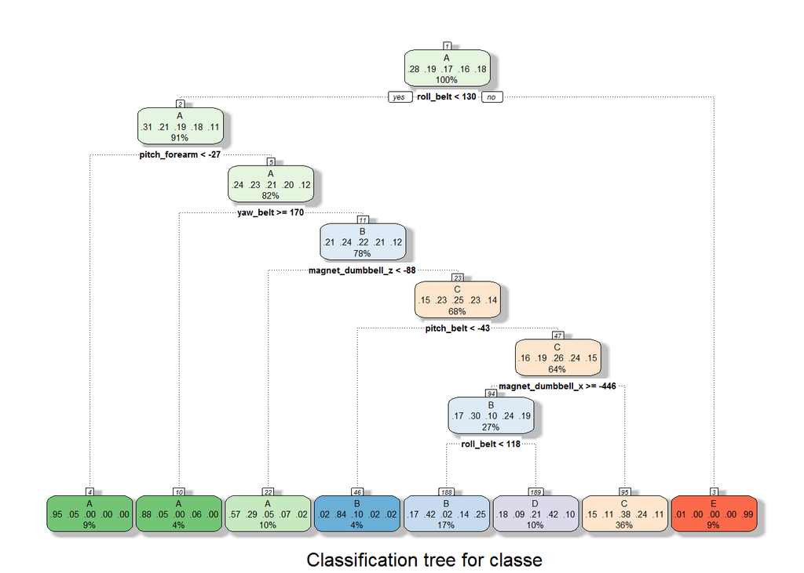

```r
fancyRpartPlot(fitClassTree$finalModel, sub = "Classification tree for classe")
```

Now, we check prediction in order to see out of sample error.

```r
predClassTree <- predict(fitClassTree, test)
confusionMatrix(predClassTree, test$classe)
```

```
## Confusion Matrix and Statistics
##
##           Reference
## Prediction    A    B    C    D    E
##          A 1408  261   38   73   22
##          B  237  881   59  187  362
##          C  433  305 1080  669  363
##          D  149   71  191  357   77
##          E    5    0    0    0  618
##
## Overall Statistics
##
##                Accuracy : 0.5537
##                  95% CI : (0.5426, 0.5647)
##     No Information Rate : 0.2845
##     P-Value [Acc > NIR] : < 2.2e-16
##
##                   Kappa : 0.4396
##  Mcnemar's Test P-Value : < 2.2e-16
##
## Statistics by Class:
##
##                      Class: A Class: B Class: C Class: D Class: E
## Sensitivity            0.6308   0.5804   0.7895   0.2776  0.42857
## Specificity            0.9298   0.8665   0.7268   0.9256  0.99922
## Pos Pred Value         0.7814   0.5104   0.3789   0.4225  0.99197
## Neg Pred Value         0.8637   0.8959   0.9424   0.8673  0.88592
## Prevalence             0.2845   0.1935   0.1744   0.1639  0.18379
## Detection Rate         0.1795   0.1123   0.1376   0.0455  0.07877
## Detection Prevalence   0.2297   0.2200   0.3632   0.1077  0.07940
## Balanced Accuracy      0.7803   0.7234   0.7581   0.6016  0.71390
```

A final visual check of the poor accuracy of this model.

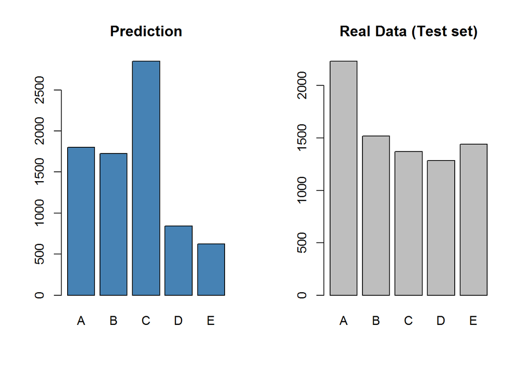

```r
par(mfrow=c(1,2))
barplot(table(predClassTree), col="steelblue", main="Prediction")
barplot(table(test$classe), col="grey", main="Real Data (Test set)")
```

### 3.2 Predictions with Boosting.

We make a second try on prediction with boosting in order to get a more accurate model.  
In this case, as boosting is more advanced model and consumes more time, we will use the partitioning of the training set just to calculate the out of sample error.

```r
fitBoost <- train(classe ~ ., data=train, method="gbm", verbose=FALSE)
fitBoost
```

```
## Stochastic Gradient Boosting
##
## 11776 samples
##    52 predictor
##     5 classes: 'A', 'B', 'C', 'D', 'E'
##
## No pre-processing
## Resampling: Bootstrapped (25 reps)
## Summary of sample sizes: 11776, 11776, 11776, 11776, 11776, 11776, ...
## Resampling results across tuning parameters:
##
##   interaction.depth  n.trees  Accuracy   Kappa
##   1                   50      0.7539904  0.6880390
##   1                  100      0.8194404  0.7713523
##   1                  150      0.8511994  0.8116031
##   2                   50      0.8527831  0.8133736
##   2                  100      0.9044130  0.8789420
##   2                  150      0.9270087  0.9075813
##   3                   50      0.8952904  0.8673416
##   3                  100      0.9366515  0.9197943
##   3                  150      0.9553505  0.9434820
##
## Tuning parameter 'shrinkage' was held constant at a value of 0.1
##
## Tuning parameter 'n.minobsinnode' was held constant at a value of 10
## Accuracy was used to select the optimal model using  the largest value.
## The final values used for the model were n.trees = 150,
##  interaction.depth = 3, shrinkage = 0.1 and n.minobsinnode = 10.
```

Let’s check how accurate is with the test test.

```r
predBoost <- predict(fitBoost, test)
confusionMatrix(predBoost, test$classe)
```

```
## Confusion Matrix and Statistics
##
##           Reference
## Prediction    A    B    C    D    E
##          A 2191   55    0    2    4
##          B   22 1423   36    8   13
##          C   12   34 1315   46   13
##          D    6    4   17 1220   28
##          E    1    2    0   10 1384
##
## Overall Statistics
##
##                Accuracy : 0.9601
##                  95% CI : (0.9555, 0.9643)
##     No Information Rate : 0.2845
##     P-Value [Acc > NIR] : < 2.2e-16
##
##                   Kappa : 0.9495
##  Mcnemar's Test P-Value : 6.582e-12
##
## Statistics by Class:
##
##                      Class: A Class: B Class: C Class: D Class: E
## Sensitivity            0.9816   0.9374   0.9613   0.9487   0.9598
## Specificity            0.9891   0.9875   0.9838   0.9916   0.9980
## Pos Pred Value         0.9729   0.9474   0.9261   0.9569   0.9907
## Neg Pred Value         0.9927   0.9850   0.9918   0.9900   0.9910
## Prevalence             0.2845   0.1935   0.1744   0.1639   0.1838
## Detection Rate         0.2793   0.1814   0.1676   0.1555   0.1764
## Detection Prevalence   0.2870   0.1914   0.1810   0.1625   0.1781
## Balanced Accuracy      0.9854   0.9625   0.9725   0.9701   0.9789
```

We can check the accuracy of this model with these plots (just a visual check which of course matches with the Confusion Matrix).

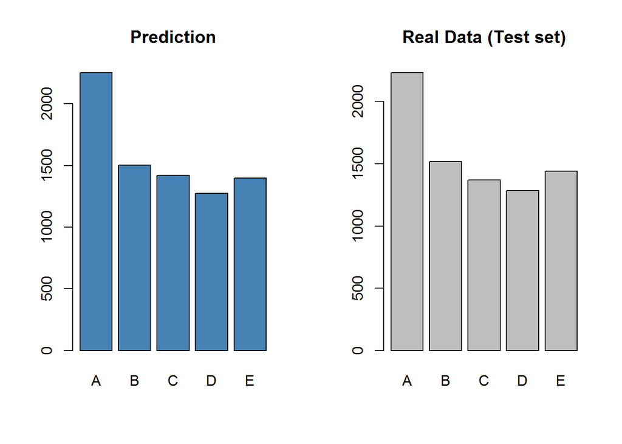

```r
par(mfrow=c(1,2))
barplot(table(predBoost), col="steelblue", main="Prediction")
barplot(table(test$classe), col="grey", main="Real Data (Test set)")
```

## 4 Prediction with Testing set.

We finally choose the model fitted with Boosting, because it got a higher accuracy, in order to predict the 20 test cases reserved from the beginning, stored in ‘testing’.

```r
predBoostFinal <- predict(fitBoost, testClean)
predBoostFinal
```

```
##  [1] B A B A A E D B A A B C B A E E A B B B
## Levels: A B C D E
```

We save these data in a csv file.

```r
prediction <- cbind(seq(1:length(predBoostFinal)), as.character(predBoostFinal))
write.csv(prediction, file = "Prediction.csv", row.names=FALSE)
```